# Analyse De Survie : Turnover En Entreprise

## Visualisation des variables qualitatives

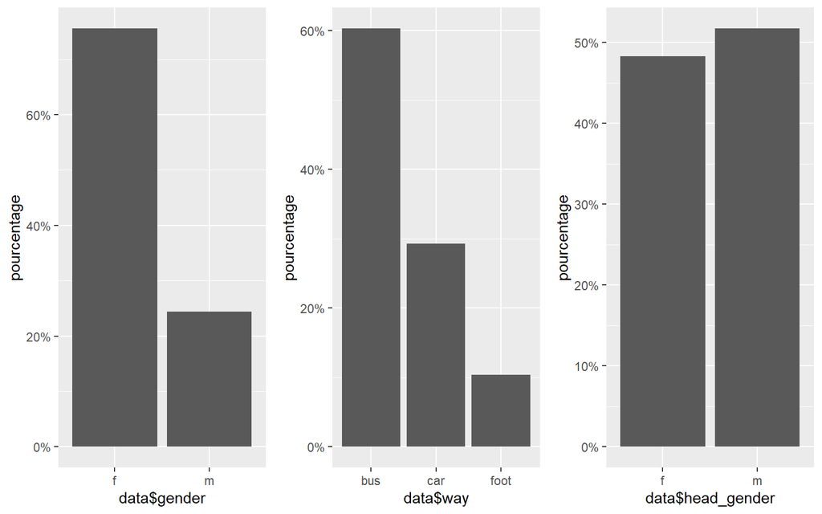

```r
bp1 <- ggplot(turno, aes(data$gender)) +
              geom_bar(aes(y = (..count..)/sum(..count..))) +
              scale_y_continuous(labels=scales::percent) +
              ylab("pourcentage")

bp2 <- ggplot(turno, aes(data$industry)) +
              geom_bar(aes(y = (..count..)/sum(..count..))) +
              scale_y_continuous(labels=scales::percent) +
              ylab("pourcentage") +
              theme(axis.text.x = element_text(angle=90, vjust=0.5, hjust=1))

bp3 <- ggplot(turno, aes(data$profession)) +
              geom_bar(aes(y = (..count..)/sum(..count..))) +
              scale_y_continuous(labels=scales::percent) +
              ylab("pourcentage") +
              theme(axis.text.x = element_text(angle=90, vjust=0.5, hjust=1))

bp4 <- ggplot(turno, aes(data$traffic)) +
              geom_bar(aes(y = (..count..)/sum(..count..))) +
              scale_y_continuous(labels=scales::percent) +
              ylab("pourcentage") +
              theme(axis.text.x = element_text(angle=90, vjust=0.5, hjust=1))

bp5 <- ggplot(turno, aes(data$way)) +
              geom_bar(aes(y = (..count..)/sum(..count..))) +
              scale_y_continuous(labels=scales::percent) +
              ylab("pourcentage")

bp6 <- ggplot(turno, aes(data$head_gender)) +
              geom_bar(aes(y = (..count..)/sum(..count..))) +
              scale_y_continuous(labels=scales::percent) +
              ylab("pourcentage")

bp7 <- ggplot(turno, aes(data$greywage)) +
              geom_bar(aes(y = (..count..)/sum(..count..))) +
              scale_y_continuous(labels=scales::percent) +
              ylab("pourcentage")

bp8 <- ggplot(turno, aes(data$coach)) +
              geom_bar(aes(y = (..count..)/sum(..count..))) +
              scale_y_continuous(labels=scales::percent) +
              ylab("pourcentage")

grid.arrange(bp1, bp5, bp6, ncol=3)
```

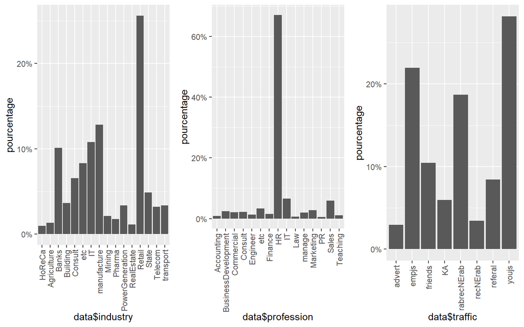

```r
grid.arrange(bp2, bp3, bp4, ncol=3)
```

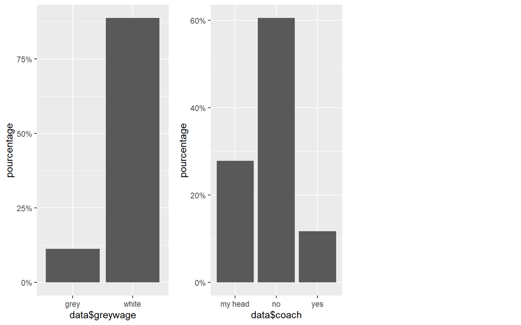

```r
grid.arrange(bp7, bp8, ncol=3)
```

On constate que pour la majorité de ces variables les classes sont très inéquitablement réparties : leur utilisation telles quelles risquerait donc d’invalider les résultats de notre étude.

Au vu du nombre de variables, certaines disposant de nombreuses modalités, nous jugeons préférable de ne pas recourir à du *resampling* pour ne pas vider notre échantillon et préférons exclure ces variables de l’étude pour nous concentrer sur celles qui suivent.

## Visualisation des variables quantitatives

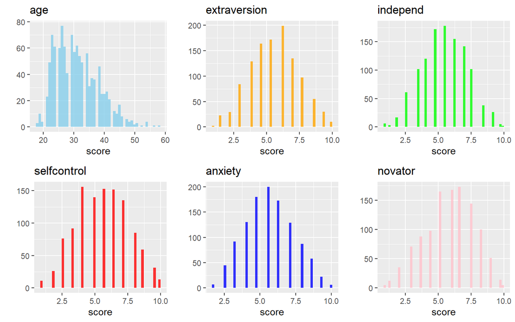

```r
h1 <- ggplot(turno, aes(x=age)) +
  geom_histogram(bins=50, fill="skyblue", alpha=0.8) +
  ggtitle("age") + xlab('score') + ylab('')
h2 <- ggplot(turno, aes(x=extraversion)) +
  geom_histogram(bins=50, fill="orange", alpha=0.8) +
  ggtitle("extraversion") + xlab('score') + ylab('')
h3 <- ggplot(turno, aes(x=independ)) +
  geom_histogram(bins=50, fill="green", alpha=0.8) +
  ggtitle("independ") + xlab('score') + ylab('')
h4 <- ggplot(turno, aes(x=selfcontrol)) +
  geom_histogram(bins=50, fill="red", alpha=0.8) +
  ggtitle("selfcontrol") + xlab('score') + ylab('')
h5 <- ggplot(turno, aes(x=anxiety)) +
  geom_histogram(bins=50, fill="blue", alpha=0.8) +
  ggtitle("anxiety") + xlab('score') + ylab('')
h6 <- ggplot(turno, aes(x=novator)) +
  geom_histogram(bins=50, fill="pink", alpha=0.8) +
  ggtitle("novator") + xlab('score') + ylab('')

grid.arrange(h1, h2, h3, h4, h5, h6, ncol=3, nrow=2)
```

Les 5 variables censées refléter les caractéristiques psychologiques de l’individu semblent suivre peu ou prou des distributions normales : pour chacune d’elles, les employés se répartissent symétriquement autour d’un score moyen.

Pour l’analyse qui suit, **nous décidons de ne conserver que ces 6 variables (âge + traits de personnalité) du dataset original** en prenant soin de les transformer en variables **qualitatives**.

On recourt à la fonction *cut_number()* pour découper chaque variable en trois classes de tailles égales. Dans le cas des variables psychologiques, on obtient ainsi :

- une classe *medium* regroupant les individus proches de la moyenne de l’échantillon ;
- une classe *low* pour les individus chez qui le trait étudié n’est pas très marqué ;
- une classe *high* pour ceux chez qui il est plutôt exacerbé.

```r
turno$age <- cut_number(turno$age, 3)
turno$extraversion <- cut_number(turno$extraversion, 3)
turno$independ <- cut_number(turno$independ, 3)
turno$selfcontrol <- cut_number(turno$selfcontrol, 3)
turno$anxiety <- cut_number(turno$anxiety, 3)
turno$novator <- cut_number(turno$novator, 3)
turno <- turno[c('stag', 'event', 'age', 'extraversion', 'independ', 'selfcontrol', 'anxiety', 'novator')]
```

**Scénario proposé :**

Afin de lutter contre les difficultés de recrutement de long-terme des entreprises du secteur, la Chambre de Commerce et d’Industrie de la région propose aux recruteurs une méthode d’évaluation psychologique des candidats qu’il reçoivent afin de déceler celles et ceux qui seraient le plus susceptibles de s’engager dans la durée au sein de leur organisation.

Au terme de la phase de test, nous avons été mandatés par la CGI pour analyser les premières données récoltées et identifier les traits de personnalité qui tendent à peser sur la probabilité pour un employé de démissionner au-delà d’un certain passé en emploi.

# 2. Estimation non-paramétrique des fonctions S, H et h

## Estimation de la fonction de survie S (Kaplan-Meyer)

Une estimation de la fonction de survie *S* à partir des observations s’obtient par la formule suivante :

$$S_{KM}(t_{i}) =
S_{t_{i-1}}(1-\frac{d_i}{n_i})$$

avec

- $S_{t_i−1}$ = la probabilité que l’évènement d’intérêt ne se soit pas encore produit à $t_{i−1}$ ;
- $n_i$ = le nombre d’observations pour lesquelles cet évènement ne s’est pas produit avant $t_i$ ;
- $d_i$ = le nombre d’observations pour lesquelles cet évènement s’est produit à l’instant $t_i$, dont on soustrait éventuellement le nombre d’observations censurées ;
- $t_0$ = 0, $S(0)$ = 1.

### Calcul de l’estimateur KM sans censure

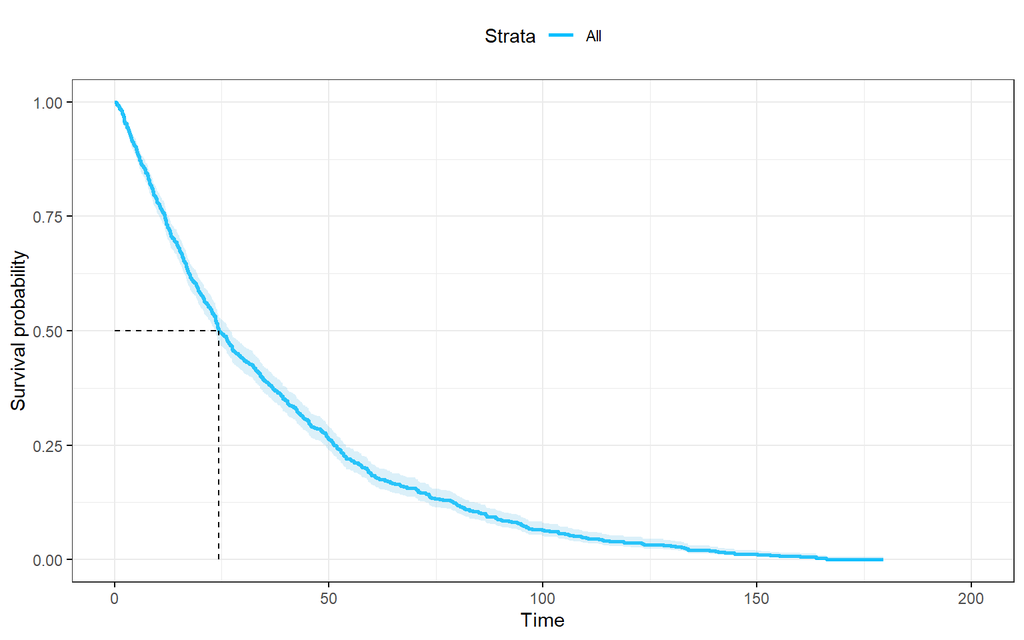

```r
nc_fit <- survfit(Surv(stag) ~ 1, data = turno)

ggsurvplot(nc_fit,
           conf.int=T,
           ggtheme = theme_bw(),
           palette='deepskyblue',
           conf.int.fill = 'skyblue',
           surv.median.line = 'hv')
```

**Interprétation**

En ignorant la censure, on constate que la probabilité qu’un employé reste en poste au-delà de 6 mois (25 semaines) est de 1/2.

On remarque plus généralement que la probabilité de maintien dans l’emploi décroît rapidement mais de moins en moins vite à mesure que le temps passe.

### Calcul de l’estimateur KM avec censure

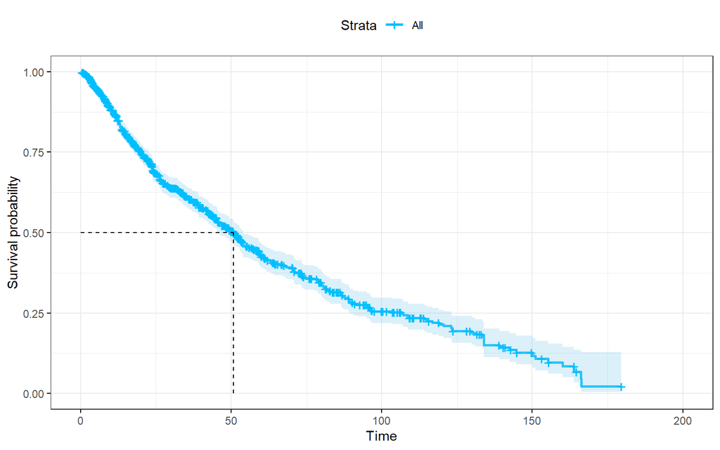

```r
fit <- survfit(Surv(stag, event) ~ 1, data = turno)

ggsurvplot(fit,
           conf.int=T,
           ggtheme = theme_bw(),
           palette='deepskyblue',
           conf.int.fill = 'skyblue',
           surv.median.line = 'hv')
```

**Interprétation**

La convexité de la fonction de survie empirique avec censure est moins marquée que dans le cas précédent : la décroissance est plus lente et régulière.

On remarque donc que la probabilité de survie atteint les 50% à partir de 1 an au lieu de 6 mois précédemment.

**On se contentera à partir de maintenant d’étudier nos données en tenant compte de la censure.**

## Estimation de la fonction de risque cumulé H (Nelson-Aalen)

La formule suivante fournit un estimateur asymptotiquement sans biais de la fonction de risque cumulé H :

$$\hat{H}(t) = \sum_{t_{i} \leq
t}\frac{d_i}{R_i}$$
avec

- $d_i$ = le nombre d’observations pour lesquelles l’évènement s’est produit dans $]t_{i-1}, t_i]$ ;
- $R_i$ = le nombre d’observations pour lesquelles l’évènement aurait pu se produire dans $]t_{i-1}, t_i]$.

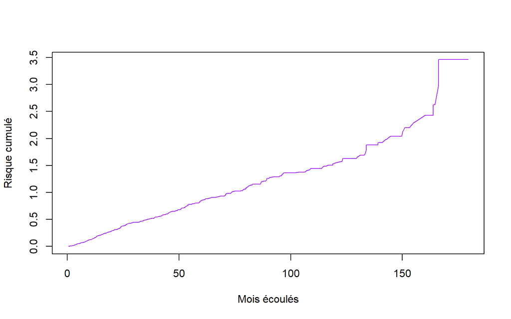

```r
H <- cumsum(fit$n.event/fit$n.risk)
plot(x=fit$time, y=H, type='l', xlab='Mois écoulés', ylab='Risque cumulé', col='purple')
```

```r
# alternativement, on peut utiliser l'objet fit$cumhaz pour obtenir cet estimateur
#plot(x=fit$time, y=fit$cumhaz, type='l', xlab='Mois écoulés', ylab='Risque cumulé', col='orangered2')
```

## Estimation de la fonction de risque instantanné h

L’estimation non-paramétrique de la fonction de risque instantanné s’obtient en dérivant la fonction de risque cumulé calculée précédemment.

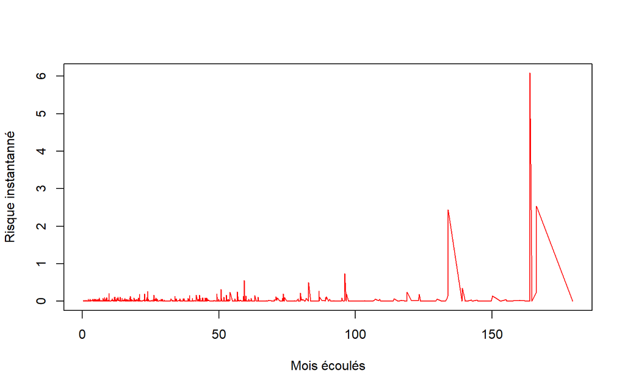

```r
h <- diff(fit$cumhaz) / diff(fit$time)
plot(x=fit$time[-1], y=h, type='l', xlab='Mois écoulés', ylab='Risque instantanné', col='red')
```

# 3. Modèles paramétriques

## Loi de Weibull

**Fonction de survie** pour une Weibull de paramètres (a, $\lambda$) :

$$S(t) = \exp^{-(\lambda t)^a}$$
a étant un paramètre de forme et $\lambda$ un paramètre d’échelle.

### Estimation explicite des paramètres de la loi via l’EMV

**Log vraisemblance** pour une Weibull de paramètres (en présence de censure) :

$$\mathcal{L}(o_1, ..., o_n, \theta) =
K+\sum_{i=1}^n [\delta_i \log(a \lambda^a t_i^{a-1}) +
log(\exp^{-(\lambda t_i)^a})]$$

```r
logL_W = function (par) {
  - sum(turno$event * (log(par[1]) - par[1]*log(par[2]) + (par[1]-1)*log(turno$stag)) - (turno$stag/par[2])**par[1])
}

estim_W <- nlm(logL_W, c(0.1, 0.1))
estim_W
```

```
## $minimum
## [1] 3014.274
##
## $estimate
## [1]  1.069137 71.133804
##
## $gradient
## [1] 8.175045e-04 2.177403e-05
##
## $code
## [1] 1
##
## $iterations
## [1] 26
```

### Estimation avec la fonction *fitdistcens*

```r
# Censure à droite ici
df <- data.frame("left"=turno$stag,"right"= rep(NA,length(turno$stag)))
df[which(turno$event==1), 'right'] <- turno[which(turno$event==1), 'stag']
fit_W <- fitdistcens(df, 'weibull')
summary(fit_W)
```

```
## Fitting of the distribution ' weibull ' By maximum likelihood on censored data
## Parameters
##        estimate Std. Error
## shape  1.069298 0.03486707
## scale 71.111365 2.83683505
## Loglikelihood:  -3014.274   AIC:  6032.548   BIC:  6042.606
## Correlation matrix:
##            shape      scale
## shape  1.0000000 -0.1952103
## scale -0.1952103  1.0000000
```

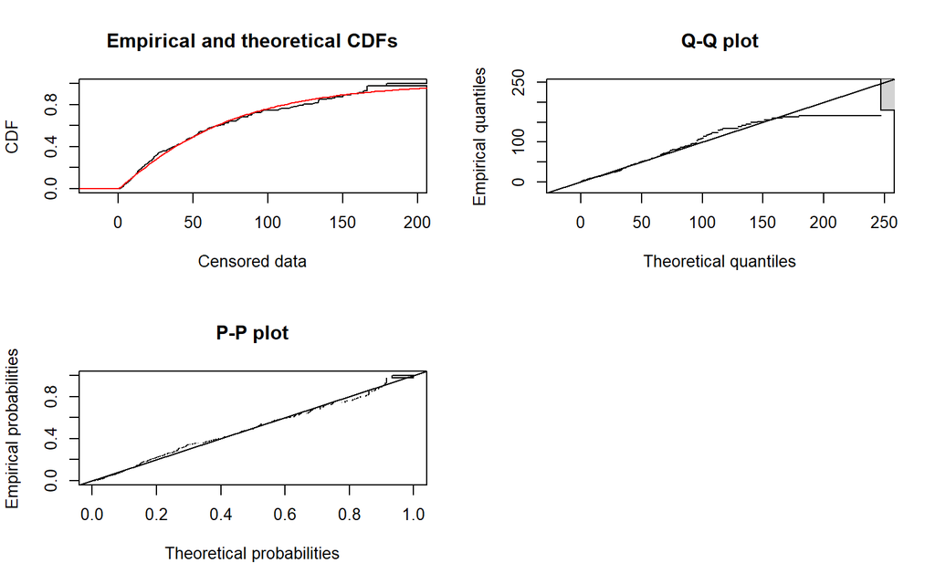

```r
plot(fit_W)
```

### Estimation avec la fonction *flexsurvreg*

```r
fit_W2 <- flexsurvreg(Surv(stag, event) ~ 1, data=turno, dist="weibull")
fit_W2
```

```
## Call:
## flexsurvreg(formula = Surv(stag, event) ~ 1, data = turno, dist = "weibull")
##
## Estimates:
##        est      L95%     U95%     se
## shape   1.0691   1.0029   1.1397   0.0349
## scale  71.1337  65.7809  76.9220   2.8393
##
## N = 1129,  Events: 571,  Censored: 558
## Total time at risk: 41352.48
## Log-likelihood = -3014.274, df = 2
## AIC = 6032.548
```

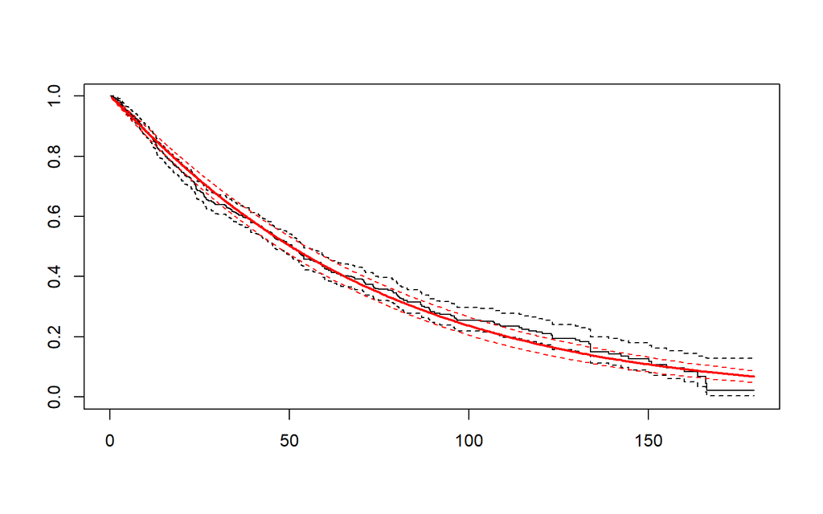

```r
plot(fit_W2)
```

## Loi exponentielle

```r
fit_E <- fitdistcens(df, 'exp')
summary(fit_E)
```

```
## Fitting of the distribution ' exp ' By maximum likelihood on censored data
## Parameters
##        estimate   Std. Error
## rate 0.01383214 0.0005758129
## Loglikelihood:  -3016.307   AIC:  6034.615   BIC:  6039.644
```

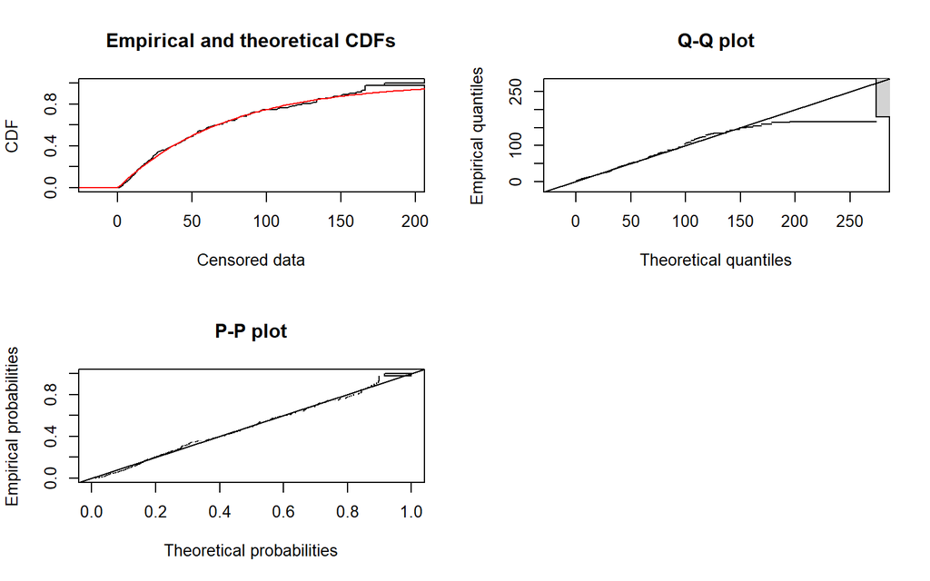

```r
plot(fit_E)
```

## Loi gamma

```r
fit_G <- fitdistcens(df, 'gamma')
summary(fit_G)
```

```
## Fitting of the distribution ' gamma ' By maximum likelihood on censored data
## Parameters
##         estimate  Std. Error
## shape 1.12570752 0.051960269
## rate  0.01624259 0.001188012
## Loglikelihood:  -3013.166   AIC:  6030.333   BIC:  6040.391
## Correlation matrix:
##           shape      rate
## shape 1.0000000 0.8478448
## rate  0.8478448 1.0000000
```

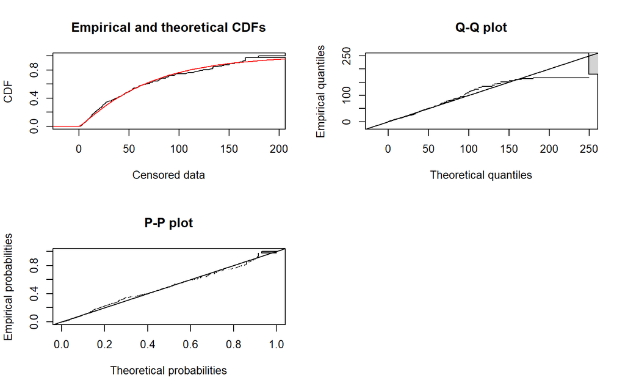

```r
plot(fit_G)
```

## Loi log-normale

```r
fit_L <- fitdistcens(df, 'lnorm')
summary(fit_L)
```

```
## Fitting of the distribution ' lnorm ' By maximum likelihood on censored data
## Parameters
##         estimate Std. Error
## meanlog 3.840301 0.04808654
## sdlog   1.302856 0.03936551
## Loglikelihood:  -3014.617   AIC:  6033.234   BIC:  6043.292
## Correlation matrix:
##          meanlog    sdlog
## meanlog 1.000000 0.362028
## sdlog   0.362028 1.000000
```

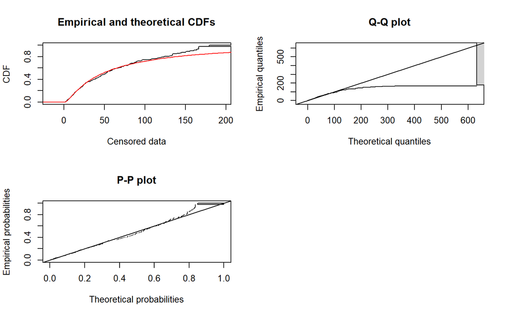

```r
plot(fit_L)
```

## Comparaison des modèles

```r
Loi <- c("Expo", "Weibull", "Gamma", "Log-Normale")
logLikelihood <- c(fit_E$loglik, fit_W$loglik, fit_G$loglik, fit_L$loglik)
AIC <- c(fit_E$aic, fit_W$aic, fit_G$aic, fit_L$aic)
BIC <- c(fit_E$bic, fit_W$bic, fit_G$bic, fit_L$bic)
scores <- tibble(Loi, logLikelihood, AIC, BIC)
print(scores)
```

```
## # A tibble: 4 × 4
##   Loi         logLikelihood   AIC   BIC
##   <chr>               <dbl> <dbl> <dbl>
## 1 Expo               -3016. 6035. 6040.
## 2 Weibull            -3014. 6033. 6043.
## 3 Gamma              -3013. 6030. 6040.
## 4 Log-Normale        -3015. 6033. 6043.
```

# 4. Intégration des cofacteurs

## Modèles non-paramétriques

Le but ici est de recalculer des estimateurs de la fonction de survie conditionnellement aux variables qualitatives que nous avons retenues en début d’étude.

On va donc estimer S pour chaque groupe constitué par les modalités de la variable considérée en tentant de voir si les fonctions obtenues sont significativement différentes, et ainsi déterminer sommairement quelles sont les modalités qui augmentent ou réduisent la probabilité de survie.

### Calcul de l’estimateur KM avec le cofacteur *age*

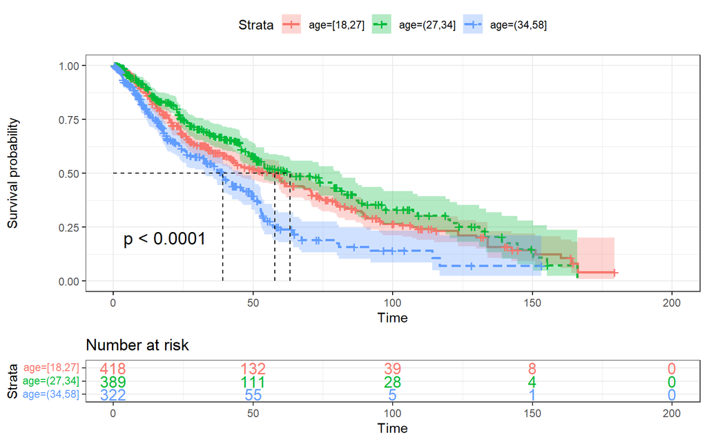

```r
fit <- survfit(Surv(stag, event) ~ age, data = turno)

ggsurvplot(fit,
          pval = TRUE, conf.int = TRUE,
          risk.table = TRUE,
          risk.table.col = "strata",
          linetype = "strata",
          surv.median.line = "hv",
          ggtheme = theme_bw())
```

**Interprétation**

Graphiquement, les trois classes que nous avons créées pour la variable *age* semblent donner des fonctions de survie bien différentes.

Cette impression est confirmée par la valeur p affichée sur le graphique et obtenue à partir du **log-rank test** qui sert précisément à déterminer si les fonctions de survie de différents groupes sont significativement différentes. La p-value très faible nous invite à rejeter l’hypothèse nulle d’égalité des fonctions S.

La différence entre les courbes est particulièrement marquée pour les plus de 34 ans qui semblent les plus enclins à démissionner comme le montre l’effondrement rapide du nombre d’individus encore à risque dans le tableau ci-dessous. Ainsi, la probabilité pour un employé de plus de 34 ans de rester au-delà d’un an semble avoisiner 1/4 contre 1/2 pour les catégories plus jeunes.

### Calcul avec le cofacteur *extraversion*

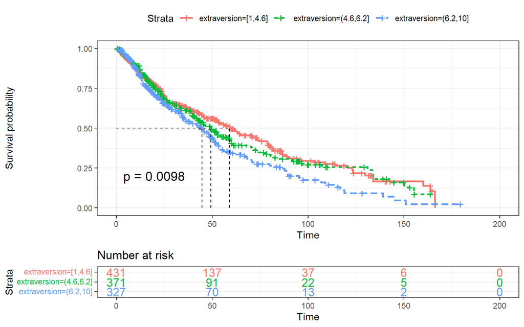

```r
fit <- survfit(Surv(stag, event) ~ extraversion, data = turno)

ggsurvplot(fit,
          pval = TRUE,
          risk.table = TRUE,
          risk.table.col = "strata",
          linetype = "strata",
          surv.median.line = "hv",
          ggtheme = theme_bw())
```

### Avec le cofacteur *anxiety*

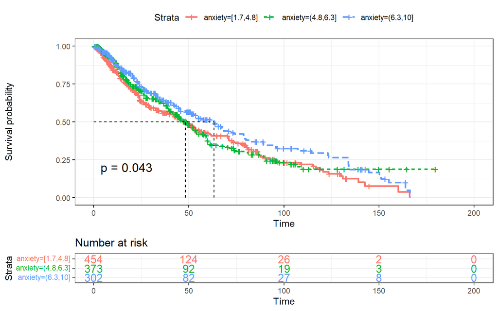

```r
fit <- survfit(Surv(stag, event) ~ anxiety, data = turno)

ggsurvplot(fit,
          pval = TRUE,
          risk.table = TRUE,
          risk.table.col = "strata",
          linetype = "strata",
          surv.median.line = "hv",
          ggtheme = theme_bw())
```

### Avec le cofacteur *novator*

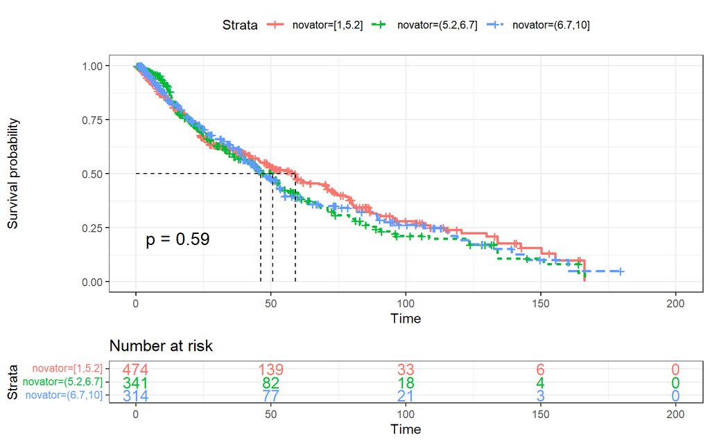

```r
fit <- survfit(Surv(stag, event) ~ novator, data = turno)

ggsurvplot(fit,
          pval = TRUE,
          risk.table = TRUE,
          risk.table.col = "strata",
          linetype = "strata",
          surv.median.line = "hv",
          ggtheme = theme_bw())
```

### Avec le cofacteur *independ*

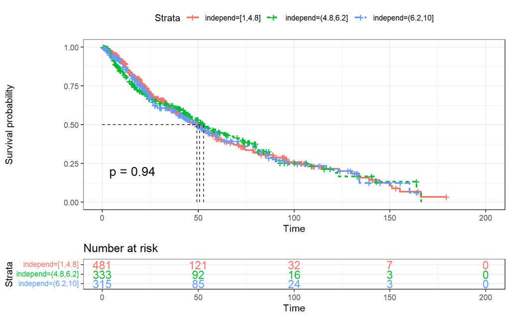

```r
fit <- survfit(Surv(stag, event) ~ independ, data = turno)

ggsurvplot(fit,
          pval = TRUE,
          risk.table = TRUE,
          risk.table.col = "strata",
          linetype = "strata",
          surv.median.line = "hv",
          ggtheme = theme_bw())
```

**Interprétation**

La p-value du log-rank test est proche de 1, indiquant que la probabilité de survie d’un employé n’est pas significativement influencée par l’indépendance de son caractère.

### Avec le cofacteur *selfcontrol*

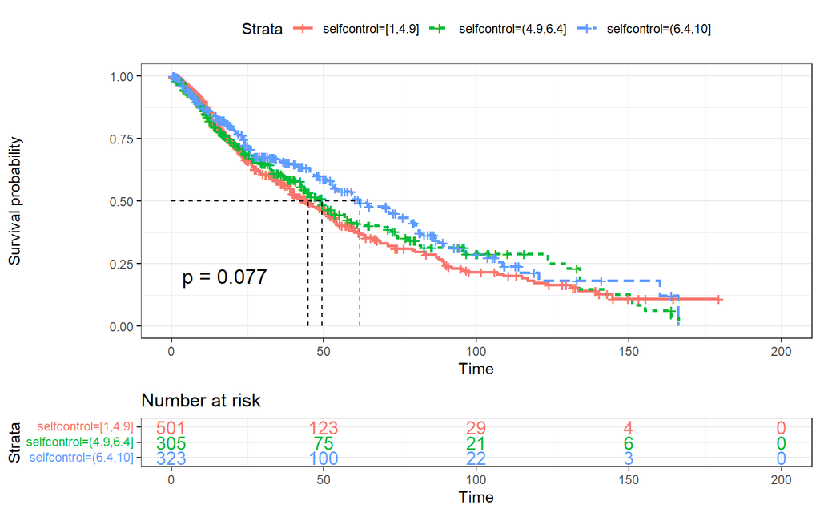

```r
fit <- survfit(Surv(stag, event) ~ selfcontrol, data = turno)

ggsurvplot(fit,
          pval = TRUE,
          risk.table = TRUE,
          risk.table.col = "strata",
          linetype = "strata",
          surv.median.line = "hv",
          ggtheme = theme_bw())
```

**Cette première approche nous invite à retenir les variables *age*, *extraversion* et *anxiety* comme cofacteurs susceptibles d’influencer la probabilité de maintien dans l’emploi d’un salarié donné.**

# 5. Modèle de Cox et sélection de variables

## Sélection par *step AIC* et *step BIC*

Les méthodes suivantes ont pour objet de détecter les variables qui affectent la probabilité de survie. Elles consistent toutes deux à tester différentes combinaisons de variables appliquées au modèle de Cox en vue de minimiser un score qui mesure la qualité de la régression tout en limitant l’ajout de paramètres superflus.

### *Step AIC*

```r
cox <- coxph(Surv(stag, event) ~ . , data= turno)
coxaic<-stepAIC(cox, direction='both', trace=FALSE)
summary(coxaic)
```

```
## Call:
## coxph(formula = Surv(stag, event) ~ age + extraversion + anxiety,
##     data = turno)
##
##   n= 1129, number of events= 571
##
##                           coef exp(coef) se(coef)      z Pr(>|z|)
## age(27,34]            -0.16252   0.85000  0.10171 -1.598  0.11009
## age(34,58]             0.46543   1.59270  0.10376  4.486 7.27e-06 ***
## extraversion(4.6,6.2]  0.09107   1.09534  0.10152  0.897  0.36968
## extraversion(6.2,10]   0.31698   1.37298  0.10303  3.077  0.00209 **
## anxiety(4.8,6.3]      -0.13405   0.87454  0.09778 -1.371  0.17037
## anxiety(6.3,10]       -0.23284   0.79228  0.10758 -2.164  0.03043 *
## ---
## Signif. codes:  0 '***' 0.001 '**' 0.01 '*' 0.05 '.' 0.1 ' ' 1
##
##                       exp(coef) exp(-coef) lower .95 upper .95
## age(27,34]               0.8500     1.1765    0.6964    1.0375
## age(34,58]               1.5927     0.6279    1.2996    1.9519
## extraversion(4.6,6.2]    1.0953     0.9130    0.8977    1.3365
## extraversion(6.2,10]     1.3730     0.7283    1.1219    1.6802
## anxiety(4.8,6.3]         0.8745     1.1435    0.7220    1.0593
## anxiety(6.3,10]          0.7923     1.2622    0.6417    0.9782
##
## Concordance= 0.589  (se = 0.013 )
## Likelihood ratio test= 47.03  on 6 df,   p=2e-08
## Wald test            = 48.8  on 6 df,   p=8e-09
## Score (logrank) test = 49.63  on 6 df,   p=6e-09
```

**Cette méthode en procédant par minimisation de l’AIC nous invite à sélectionner le modèle intégrant les variables *age*, *extraversion* et *anxiety* comme cofacteurs pertinents.** **On retrouve donc nos conclusions établies précédemment avec les modèles non-paramétriques.**

### *Step BIC*

```r
coxbic = stepAIC(cox, direction = "both", k = log(length(turno$stag)), trace= F)
summary(coxbic)
```

```
## Call:
## coxph(formula = Surv(stag, event) ~ age, data = turno)
##
##   n= 1129, number of events= 571
##
##               coef exp(coef) se(coef)      z Pr(>|z|)
## age(27,34] -0.1672    0.8461   0.1017 -1.644      0.1
## age(34,58]  0.4418    1.5555   0.1032  4.281 1.86e-05 ***
## ---
## Signif. codes:  0 '***' 0.001 '**' 0.01 '*' 0.05 '.' 0.1 ' ' 1
##
##            exp(coef) exp(-coef) lower .95 upper .95
## age(27,34]    0.8461     1.1819    0.6932     1.033
## age(34,58]    1.5555     0.6429    1.2707     1.904
##
## Concordance= 0.566  (se = 0.013 )
## Likelihood ratio test= 31.23  on 2 df,   p=2e-07
## Wald test            = 32.83  on 2 df,   p=7e-08
## Score (logrank) test = 33.58  on 2 df,   p=5e-08
```

**La méthode employant le BIC nous amène quant à elle à privilégier un modèle intégrant uniquement le cofacteur *age*.**

## Application au modèle de Cox et interprétation

On se sert ici des conclusions du *step AIC* en ajustant le modèle de Cox sur les variables *age*, *extraversion* et *anxiety*.

```r
cox2 <- coxph(Surv(stag, event) ~ age + extraversion + anxiety, data= turno)
summary(cox2)
```

```
## Call:
## coxph(formula = Surv(stag, event) ~ age + extraversion + anxiety,
##     data = turno)
##
##   n= 1129, number of events= 571
##
##                           coef exp(coef) se(coef)      z Pr(>|z|)
## age(27,34]            -0.16252   0.85000  0.10171 -1.598  0.11009
## age(34,58]             0.46543   1.59270  0.10376  4.486 7.27e-06 ***
## extraversion(4.6,6.2]  0.09107   1.09534  0.10152  0.897  0.36968
## extraversion(6.2,10]   0.31698   1.37298  0.10303  3.077  0.00209 **
## anxiety(4.8,6.3]      -0.13405   0.87454  0.09778 -1.371  0.17037
## anxiety(6.3,10]       -0.23284   0.79228  0.10758 -2.164  0.03043 *
## ---
## Signif. codes:  0 '***' 0.001 '**' 0.01 '*' 0.05 '.' 0.1 ' ' 1
##
##                       exp(coef) exp(-coef) lower .95 upper .95
## age(27,34]               0.8500     1.1765    0.6964    1.0375
## age(34,58]               1.5927     0.6279    1.2996    1.9519
## extraversion(4.6,6.2]    1.0953     0.9130    0.8977    1.3365
## extraversion(6.2,10]     1.3730     0.7283    1.1219    1.6802
## anxiety(4.8,6.3]         0.8745     1.1435    0.7220    1.0593
## anxiety(6.3,10]          0.7923     1.2622    0.6417    0.9782
##
## Concordance= 0.589  (se = 0.013 )
## Likelihood ratio test= 47.03  on 6 df,   p=2e-08
## Wald test            = 48.8  on 6 df,   p=8e-09
## Score (logrank) test = 49.63  on 6 df,   p=6e-09
```

Les p-values associées aux modalités affichées nous indiquent que **l’influence des trois variables est significative à condition néanmoins de considérer les classes extrêmes**, celle correspondant au *medium* étant finalement toujours très proche de celle correspondant au *low* en termes d’influence sur la probabilité de démission.

Les résultats ci-dessus nous fournissent en outre une idée du sens de cette influence. La colonne *coef* nous donne la valeur de $\beta$ et la colonne *exp(coef)* celle de $\exp(\beta)$, soit celle du **hazard ratio ($HR$)** qui correspond au rapport du risque induit par la modalité par rapport à celle utilisée comme base.

**En prenant la variable *age*, on constate ainsi que le risque de démission augmente significativement pour les salariés de plus 34 ans par rapport à ceux qui en ont moins de 27 puisque $HR > 1$.**

**On relève de la même manière que le risque de départ augmente significativement avec l’extraversion et diminue significativement lorsque le salarié s’avère particulièrement anxieux.**

## Diagnostic a posteriori du modèle

### Hypothèse de hasard proportionnel

Le modèle de Cox n’est valide que sous l’hypothèse de hasard proportionnel (HP) qui indique l’invariance dans le temps du rapport des risques.

Celle-ci peut être éprouvée via le test de Schoenfeld dont elle constitue l’hypothèse nulle. Ce test est basé sur les résidus de Schoenfeld qui donne également lieu à des représentations graphiques permettant d’évaluer la validité de H0 : il faut pour cela qu’aucun graphique (il y en a un par variable) ne montre une tendance temporelle.

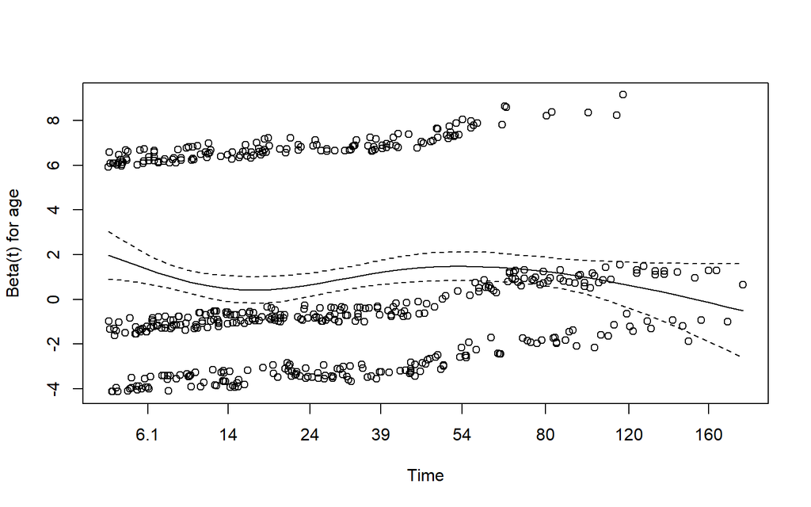

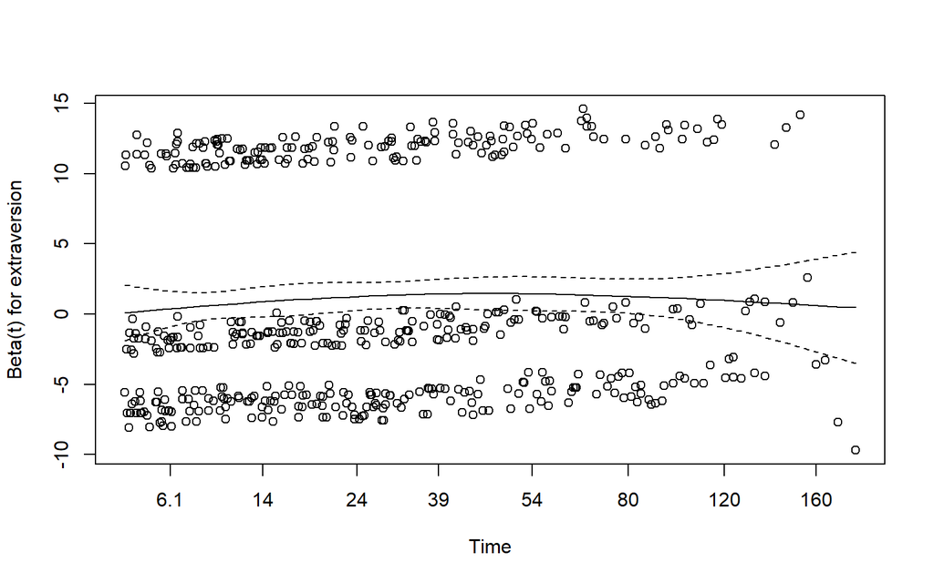

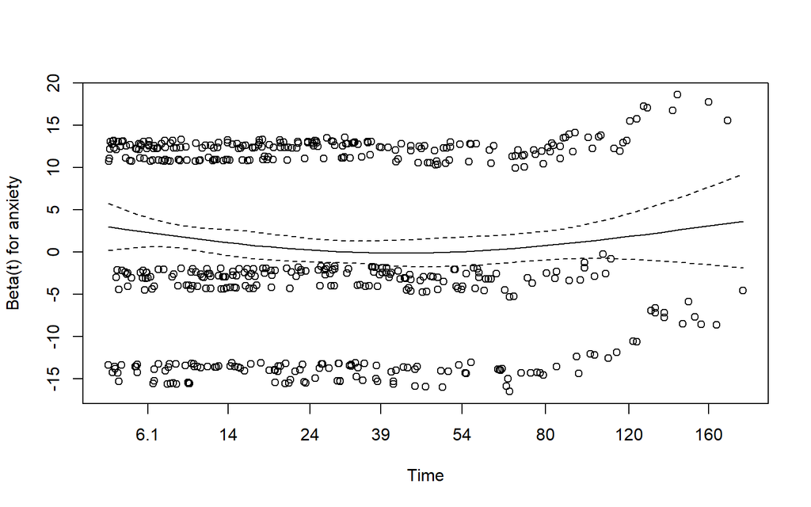

```r
schoen = cox.zph(cox2)

plot(schoen)
```

On constate que chaque graphique affiche un semblant droite horizontale, à l’exception peut-être du premier qui n’affiche cependant ni croissance ni décroissance très marquée.

Visuellement, nous sommes donc amenés à ne pas rejeter l’hypothèse nulle.

```r
schoen
```

```
##              chisq df    p
## age          1.099  2 0.58
## extraversion 0.746  2 0.69
## anxiety      0.774  2 0.68
## GLOBAL       2.906  6 0.82
```

Les p-values issues du test nous confortent dans ce sens. **On retient donc l’hypothèse HP.**

### Hypothèse de log-linéarité

On procède encore une fois par test graphique.

**Résidus des martingales**

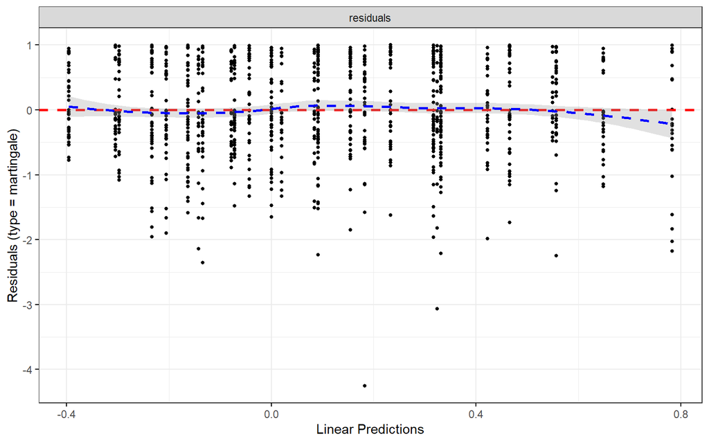

```r
ggcoxdiagnostics(cox2,type = "martingale")
```

**Résidus de la déviance**

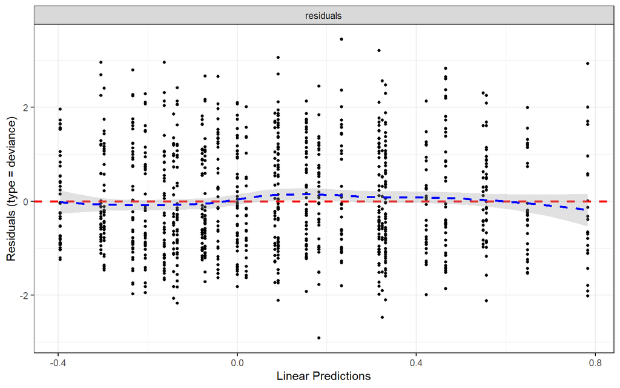

```r
ggcoxdiagnostics(cox2, type = "deviance", ox.scale = "linear.predictions")
```

Sur les deux représentations suivantes, on constate que la courbe bleue ne présente pas de forme particulière : **on en déduit que la log-linéarité est respectée**.